# PML Project - Predicting Classe

Jordan Cheah

May 23, 2015

## Summary

The goal of the project is to predict the manner in which people did the exercise. This is the “classe” variable in the training set. Two models, Fitting Single Tree and Random Forest, are used and results are cross-validated. Accuracy of both models are 54% and 99% respectively. Data Source is http://groupware.les.inf.puc-rio.br/har

### Data Loading

To ensure the results is reproducible, seed is set and required libraries are loaded, and NAs are set appropriately when reading data.

```r
set.seed(8888)
library(caret)
etr <- read.csv('pml-training.csv', na.strings = c("", "NA", "#DIV/0!"))
ett <- read.csv('pml-testing.csv', na.strings = c("", "NA", "#DIV/0!"))
# summary(etr)
```

### Data Simplification

In this part of the process, unnecessary columns, near-zero variance columns and NA columns are removed.

```r
etr <- etr[, -grep("X|user_name|cvtd_timestamp", names(etr))]  # Remove visibly unwanted columns
etr <- etr[, -nearZeroVar(etr)]   # Remove near zero variance columns
# dim(etr) is now 19622 x 121
NAs <- apply(etr, 2, function(x) { sum(is.na(x)) })   # class(NAs) is integer[1:121]
etr <- etr[, which(NAs == 0)]  # keep columns which has no NA
# dim(etr) is now 19622 x 56
```

### Data Partitioning

We split the data sets 20/80 i.e. 20% for training, and 80% for cross validation.

```r
i <- createDataPartition(y = etr$classe, p = 0.2, list = FALSE)
etr1 <- etr[i, ]   # 3927 obs. of 56 variables, 20% of original training data
etr2 <- etr[-i, ]  # test set for cross validation, 80% of original training data
```

## Model Creation #1: Classification Tree (rpart)

We perform a classification tree using the caret package with method = rpart.

```r
mf1 <- train(etr1$classe ~ ., data = etr1, method = "rpart")
mf1
```

```
## CART
##
## 3927 samples
##   55 predictor
##    5 classes: 'A', 'B', 'C', 'D', 'E'
##
## No pre-processing
## Resampling: Bootstrapped (25 reps)
##
## Summary of sample sizes: 3927, 3927, 3927, 3927, 3927, 3927, ...
##
## Resampling results across tuning parameters:
##
##   cp          Accuracy   Kappa       Accuracy SD  Kappa SD
##   0.03966560  0.5397468  0.40283656  0.07630816   0.11989556
##   0.05745286  0.4373943  0.24049459  0.07940878   0.13095760
##   0.12166489  0.3290173  0.06773419  0.04393780   0.06652919
##
## Accuracy was used to select the optimal model using  the largest value.
## The final value used for the model was cp = 0.0396656.
```

```r
r1 <- mf1$results
round(max(r1$Accuracy), 4) * 100
```

```
## [1] 53.97
```

*Conclusion: The accuracy of the model is 53.97% which is low.*

## Model Creation #2: Random Forest

A prediction model is created using Random Forest. Note that the train() function can take sometime to run.

```r
tc <- trainControl(method = "cv", number = 4, allowParallel = TRUE)
mf2 <- train(etr1$classe ~ ., data=etr1, method = "rf", prof = TRUE, trControl = tc)
mf2
```

```
## Random Forest
##
## 3927 samples
##   55 predictor
##    5 classes: 'A', 'B', 'C', 'D', 'E'
##
## No pre-processing
## Resampling: Cross-Validated (4 fold)
##
## Summary of sample sizes: 2945, 2945, 2946, 2945
##
## Resampling results across tuning parameters:
##
##   mtry  Accuracy   Kappa      Accuracy SD  Kappa SD
##    2    0.9735177  0.9664840  0.003710084  0.004702425
##   28    0.9885417  0.9855077  0.003841730  0.004857890
##   55    0.9880325  0.9848645  0.005081078  0.006423883
##
## Accuracy was used to select the optimal model using  the largest value.
## The final value used for the model was mtry = 28.
```

```r
# summary(mf2)
r2 <- mf2$results
round(max(r2$Accuracy), 4) * 100
```

```
## [1] 98.85
```

## Cross-Validation

We use the chosen prediction model from Random Forest to predict new values etr2 (contains 80% of data).

```r
pred <- predict(mf2, etr2)
etr2$predRight <- pred == etr2$classe
table(pred, etr2$classe)
```

```
##
## pred    A    B    C    D    E
##    A 4452   36    0    0    0
##    B   11 2972   33    0    8
##    C    0   29 2704   46    9
##    D    1    0    0 2520   21
##    E    0    0    0    6 2847
```

```r
r3 <- postResample(pred, etr2$classe)
r3
```

```
##  Accuracy     Kappa
## 0.9872571 0.9838790
```

## Out-of-Sample Error / Confusion Matrix

We calculated the out of sample error from etr2 (contains 80% of data).

```r
confusionMatrix(pred, etr2$classe)
```

```
## Confusion Matrix and Statistics
##
##           Reference
## Prediction    A    B    C    D    E
##          A 4452   36    0    0    0
##          B   11 2972   33    0    8
##          C    0   29 2704   46    9
##          D    1    0    0 2520   21
##          E    0    0    0    6 2847
##
## Overall Statistics
##
##                Accuracy : 0.9873
##                  95% CI : (0.9854, 0.989)
##     No Information Rate : 0.2844
##     P-Value [Acc > NIR] : < 2.2e-16
##
##                   Kappa : 0.9839
##  Mcnemar's Test P-Value : NA
##
## Statistics by Class:
##
##                      Class: A Class: B Class: C Class: D Class: E
## Sensitivity            0.9973   0.9786   0.9879   0.9798   0.9868
## Specificity            0.9968   0.9959   0.9935   0.9983   0.9995
## Pos Pred Value         0.9920   0.9828   0.9699   0.9913   0.9979
## Neg Pred Value         0.9989   0.9949   0.9974   0.9960   0.9970
## Prevalence             0.2844   0.1935   0.1744   0.1639   0.1838
## Detection Rate         0.2837   0.1894   0.1723   0.1606   0.1814
## Detection Prevalence   0.2860   0.1927   0.1776   0.1620   0.1818
## Balanced Accuracy      0.9971   0.9872   0.9907   0.9891   0.9932
```

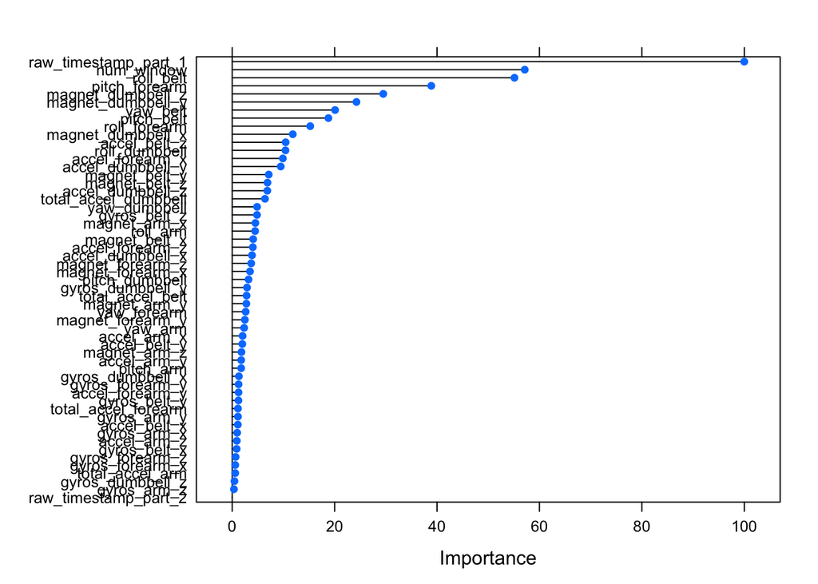

```r
plot( varImp(mf2) )
```

## 20 Test Cases - Predictions using Random Forest

```r
pred2 <- predict(mf2, ett)
p <- ett
p$classe <- pred2

pml_write_files = function(x) {
    n = length(x)
    for (i in 1:n) {
        filename = paste0("problem_id_", i, ".txt")
        write.table(x[i], file = filename, quote = FALSE, row.names = FALSE,
            col.names = FALSE)
    }
}

answers <- p$classe
pml_write_files(answers)
answers
```

```
##  [1] B A B A A E D B A A B C B A E E A B B B
## Levels: A B C D E
```